# CS1950_Week03_FDG

Hunsi Jayaprakash

2/4/2022

## Load packages

```r
library(tidyverse)
file_name <- ("https://raw.githubusercontent.com/jyurko/cs_1950_brain_proj/main/KLU_APC2_Master_2021_07_07.csv?token=GHSAT0AAAAAABQQ7BMCOBSTBU3XSIKIUTKEYQGUGLQ")
df <- readr::read_csv(file_name,col_names = TRUE)
```

## Check unique identifiers

The number of rows associated with each `Vault_Scan_ID`.

```r
df %>%
  count(Vault_Scan_ID)
```

```
## # A tibble: 190 x 2
##    Vault_Scan_ID     n
##            <dbl> <int>
##  1        800569     1
##  2        800570     1
##  3        800571     1
##  4        800572     1
##  5        800573     1
##  6        800574     1
##  7        800575     1
##  8        800684     1
##  9        800685     1
## 10        800686     1
## # ... with 180 more rows
```

The count for the number of rows associated with each `Vault_Scan_ID`.

```r
df %>%
  count(Vault_Scan_ID) %>%
  count(n, name = "times_occuring")
```

```
## # A tibble: 2 x 2
##       n times_occuring
##   <int>          <int>
## 1     1            189
## 2     2              1
```

So there is one `Vault_Scan_ID` that occurs twice, check which one:  
Vault_Scan_ID = 802688 occurs twice

```r
df %>%
  count(Vault_Scan_ID) %>%
  filter(n > 1)
```

```
## # A tibble: 1 x 2
##   Vault_Scan_ID     n
##           <dbl> <int>
## 1        802688     2
```

Look at the rows associated with that `Vault_Scan_ID` value along with the `Vault_UID` value.

```r
vault_id_focus <- df %>%
  count(Vault_Scan_ID) %>%
  filter(n > 1) %>%
  pull(Vault_Scan_ID)
df %>%
  select(Vault_Scan_ID, Vault_UID) %>%
  filter(Vault_Scan_ID %in% vault_id_focus)
```

```
## # A tibble: 2 x 2
##   Vault_Scan_ID Vault_UID
##           <dbl>     <dbl>
## 1        802688    900534
## 2        802688    900534
```

Include columns involving date in the column name.

```r
df %>%
  select(Vault_Scan_ID, Vault_UID, ends_with("_date", ignore.case = TRUE)) %>%
  filter(Vault_Scan_ID %in% vault_id_focus)
```

```
## # A tibble: 2 x 7
##   Vault_Scan_ID Vault_UID MR_Scan_Date        PET_Scan_Date Cog_Test_Date
##           <dbl>     <dbl> <dttm>              <chr>         <chr>
## 1        802688    900534 2015-11-23 00:00:00 NaN           NaN
## 2        802688    900534 2015-11-23 00:00:00 NaN           NaN
## # ... with 2 more variables: PIB_Scan_Date <dttm>, FDG_Scan_Date <dttm>
```

Check columns that contain “ID” in the column name.

```r
df %>%
  select(Vault_Scan_ID, Vault_UID, contains("ID", ignore.case = FALSE)) %>%
  filter(Vault_Scan_ID %in% vault_id_focus)
```

```
## # A tibble: 2 x 5
##   Vault_Scan_ID Vault_UID GPNID_VisitNum Nebes_ID UniqueID
##           <dbl>     <dbl> <chr>             <dbl> <chr>
## 1        802688    900534 0134DL108         16037 0134DL
## 2        802688    900534 0134DL108         16037 0134DL
```

**What other identifiers should be considered here??** Identifiers to include : age, sex, race, education , APOE_allele, PiB Regional values Left , PiB regional Right, PiB Global Values , GMD regional Left, GMD right, GMD global, FDG Regional left, FDG regional Right, FDG global

How many unique people are there? And how many rows are associated with each unique person? n = 93 ; max number of rows associated with a unique person is 4

```r
df %>%
  count(Vault_UID) %>%
  arrange(desc(n))
```

```
## # A tibble: 93 x 2
##    Vault_UID     n
##        <dbl> <int>
##  1    900643     4
##  2    900645     4
##  3    900719     4
##  4    900721     4
##  5    901382     4
##  6    901383     4
##  7    900534     3
##  8    900536     3
##  9    900644     3
## 10    900648     3
## # ... with 83 more rows
```

```r
df %>%
  count(Vault_UID) %>%
  count(n, name='times_occurs')
```

```
## # A tibble: 4 x 2
##       n times_occurs
##   <int>        <int>
## 1     1           33
## 2     2           28
## 3     3           26
## 4     4            6
```

## FDG Exploration

Extract the FDG related variables along with the unique identifiers.

**Will need to do this again based on the unique identifiers that should be included.**

```r
fdg_df <- df %>% select(Vault_Scan_ID, Vault_UID, starts_with("FDG_"))
fdg_df %>% glimpse()
```

```
## Rows: 191
## Columns: 66
## $ Vault_Scan_ID                           <dbl> 800569, 800570, 800571, 800572~
## $ Vault_UID                               <dbl> 900534, 900535, 900536, 900537~
## $ FDG_Scan_Date                           <dttm> 2010-06-25, 2010-07-08, 2010-~
## $ FDG_SUVR_GTM_FS_AnteriorCingulate       <dbl> 1.231352, 1.257970, 1.392040, ~
## $ FDG_SUVR_GTM_FS_AnteriorVentralStriatum <dbl> 0.9778522, 0.8627887, 1.076510~
## $ FDG_SUVR_GTM_FS_SuperiorFrontal         <dbl> 1.600496, 1.728087, 1.625942, ~
## $ FDG_SUVR_GTM_FS_OrbitoFrontal           <dbl> 1.277561, 1.405532, 1.459465, ~
## $ FDG_SUVR_GTM_FS_Insula                  <dbl> 1.0812875, 1.0413283, 1.081150~
## $ FDG_SUVR_GTM_FS_LateralTemporal         <dbl> 1.283741, 1.372627, 1.291083, ~
## $ FDG_SUVR_GTM_FS_Parietal                <dbl> 1.580677, 1.708970, 1.441387, ~
## $ FDG_SUVR_GTM_FS_PosteriorCingulate      <dbl> 1.561955, 1.596400, 1.637635, ~
## $ FDG_SUVR_GTM_FS_Precuneus               <dbl> 1.846800, 1.905793, 1.730991, ~
## $ FDG_SUVR_GTM_FS_Global                  <dbl> 1.478042, 1.572968, 1.474505, ~
```

[output cut: 53 more lines]

Focusing on the variables with `FDG_regional_` naming patterns.

```r
fdg_regional_wf <- fdg_df %>%
  select(starts_with("Vault"), FDG_Scan_Date, starts_with("FDG_regional"))
fdg_regional_wf %>% glimpse()
```

```
## Rows: 191
## Columns: 56
## $ Vault_Scan_ID                     <dbl> 800569, 800570, 800571, 800572, 8005~
## $ Vault_UID                         <dbl> 900534, 900535, 900536, 900537, 9005~
## $ FDG_Scan_Date                     <dttm> 2010-06-25, 2010-07-08, 2010-07-15,~
## $ FDG_regional_Caudate_L            <dbl> 0.8873898, 0.8284909, 0.8751414, 0.7~
## $ FDG_regional_Caudate_R            <dbl> 1.0652711, 0.9962705, 0.7884839, 0.8~
## $ FDG_regional_Frontal_Inf_Oper_L   <dbl> 0.8261272, 1.0248518, 0.7752054, 0.8~
## $ FDG_regional_Frontal_Inf_Oper_R   <dbl> 0.9013592, 0.9888792, 0.8044395, 0.9~
## $ FDG_regional_Frontal_Inf_Orb_2_L  <dbl> 0.8016371, 0.9887007, 0.7940145, 0.8~
## $ FDG_regional_Frontal_Inf_Orb_2_R  <dbl> 0.9925011, 0.7671593, 0.8394297, 0.8~
## $ FDG_regional_Frontal_Inf_Tri_L    <dbl> 0.7777354, 1.0483644, 0.7367038, 0.8~
## $ FDG_regional_Frontal_Inf_Tri_R    <dbl> 0.9114206, 0.9698973, 0.7744250, 1.0~
## $ FDG_regional_Frontal_Med_Orb_L    <dbl> 0.9431620, 1.1247162, 0.9846138, 0.9~
## $ FDG_regional_Frontal_Med_Orb_R    <dbl> 0.8834587, 1.1444259, 0.9080860, 0.9~
```

[output cut: 43 more lines]

Check number of missings per column.

```r
fdg_regional_wf %>% purrr::map_dbl(~sum(is.na(.)))
```

```
##                     Vault_Scan_ID                         Vault_UID
##                                 0                                 0
##                     FDG_Scan_Date            FDG_regional_Caudate_L
##                                61                                21
##            FDG_regional_Caudate_R   FDG_regional_Frontal_Inf_Oper_L
##                                21                                21
##   FDG_regional_Frontal_Inf_Oper_R  FDG_regional_Frontal_Inf_Orb_2_L
##                                21                                21
##  FDG_regional_Frontal_Inf_Orb_2_R    FDG_regional_Frontal_Inf_Tri_L
##                                21                                21
##    FDG_regional_Frontal_Inf_Tri_R    FDG_regional_Frontal_Med_Orb_L
##                                21                                21
##    FDG_regional_Frontal_Med_Orb_R      FDG_regional_Frontal_Mid_2_L
##                                21                                21
##      FDG_regional_Frontal_Mid_2_R      FDG_regional_Frontal_Sup_2_L
##                                21                                20
##      FDG_regional_Frontal_Sup_2_R FDG_regional_Frontal_Sup_Medial_L
##                                21                                21
## FDG_regional_Frontal_Sup_Medial_R           FDG_regional_Fusiform_L
##                                21                                21
##           FDG_regional_Fusiform_R             FDG_regional_Heschl_L
##                                21                                21
##             FDG_regional_Heschl_R             FDG_regional_Insula_L
##                                21                                21
##             FDG_regional_Insula_R             FDG_regional_OFCant_L
##                                21                                21
##             FDG_regional_OFCant_R           FDG_regional_Pallidum_L
##                                21                                21
##           FDG_regional_Pallidum_R    FDG_regional_ParaHippocampal_L
##                                21                                21
##    FDG_regional_ParaHippocampal_R       FDG_regional_Parietal_Inf_L
##                                21                                20
##       FDG_regional_Parietal_Inf_R        FDG_regional_Postcentral_L
##                                21                                20
##        FDG_regional_Postcentral_R         FDG_regional_Precentral_L
##                                21                                20
##         FDG_regional_Precentral_R            FDG_regional_Putamen_L
##                                21                                21
##            FDG_regional_Putamen_R             FDG_regional_Rectus_L
##                                21                                21
##             FDG_regional_Rectus_R      FDG_regional_Rolandic_Oper_L
##                                21                                21
##      FDG_regional_Rolandic_Oper_R      FDG_regional_SupraMarginal_L
##                                21                                20
##      FDG_regional_SupraMarginal_R       FDG_regional_Temporal_Inf_L
##                                21                                21
##       FDG_regional_Temporal_Inf_R       FDG_regional_Temporal_Mid_L
##                                21                                21
##       FDG_regional_Temporal_Mid_R  FDG_regional_Temporal_Pole_Mid_L
##                                21                                21
##  FDG_regional_Temporal_Pole_Mid_R  FDG_regional_Temporal_Pole_Sup_L
##                                21                                21
##  FDG_regional_Temporal_Pole_Sup_R       FDG_regional_Temporal_Sup_L
##                                21                                20
##       FDG_regional_Temporal_Sup_R  FDG_regional_Frontal_Sup_2_asymm
##                                21                                21
```

Distribution of the FDG regional variables across all rows. This ignores any grouping by people.

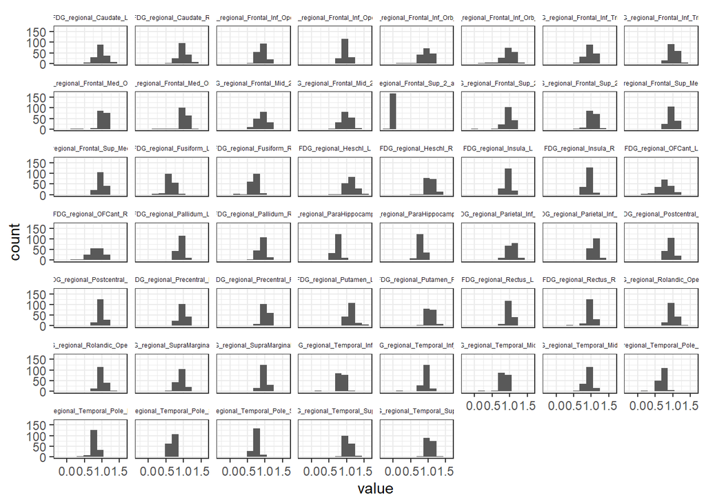

```r
fdg_regional_wf %>%
  tibble::rowid_to_column() %>%
  pivot_longer(cols = starts_with("FDG_regional")) %>%
  ggplot(mapping = aes(x = value)) +
  geom_histogram(bins = 10) +
  facet_wrap(~name) +
  theme_bw() +
  theme(strip.background = element_blank(),
        strip.text = element_text(size = 4.5))
```

Use boxplots instead.

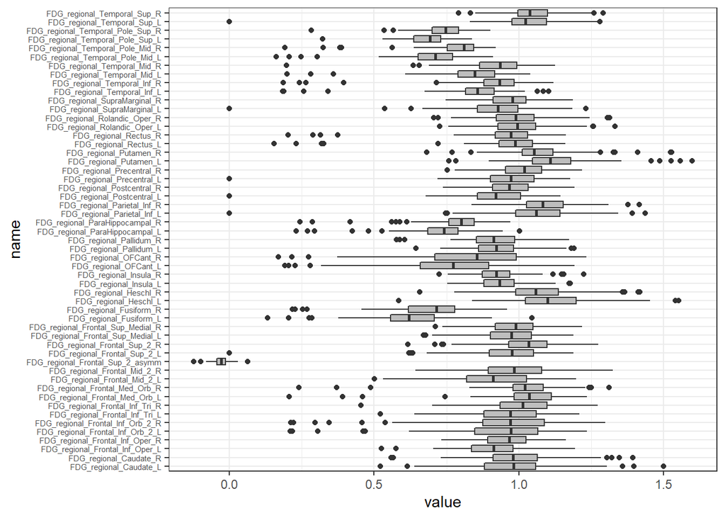

```r
fdg_regional_wf %>%
  tibble::rowid_to_column() %>%
  pivot_longer(cols = starts_with("FDG_regional")) %>%
  ggplot(mapping = aes(y = name, x = value)) +
  geom_boxplot(fill = 'grey') +
  theme_bw() +
  theme(axis.text.y = element_text(size = 5.5))
```

Start to parse the regional variable names.

Create a helper function to separate the variable names based on the `'_'` pattern. The helper function is required because the number of underscores is not consistent across the regional names.

```r
my_separate <- function(the_data, num_us)
{
  names_keep <- the_data %>% select(-name) %>% names()

  the_data %>%
    tidyr::separate(name,
                    c("result_type", "regional_word",
                      sprintf("name_%02d", 1:(num_us-1))),
                    sep = "_") %>%
    rename(!!!c("side_name" = sprintf("name_%02d", num_us-1))) %>%
    tidyr::unite("region_name",
                 sprintf("name_%02d", 1:(num_us-2)),
                 sep = "_") %>%
    select(all_of(c(names_keep,
                    "result_type", "region_name", "side_name")))
}
```

Apply the helper function based on the number of underscores to create the long-format data.

```r
fdg_regional_lf <- fdg_regional_wf %>%
  tibble::rowid_to_column() %>%
  pivot_longer(cols = starts_with("FDG_regional")) %>%
  mutate(num_underscores = stringr::str_count(name, pattern = "_")) %>%
  group_by(num_underscores) %>%
  tidyr::nest() %>%
  mutate(ready_data = purrr::map2(data, num_underscores, my_separate)) %>%
  select(num_underscores, ready_data) %>%
  tidyr::unnest(ready_data) %>%
  ungroup()
```

Check the unique region names and the number of rows associated with each region name.

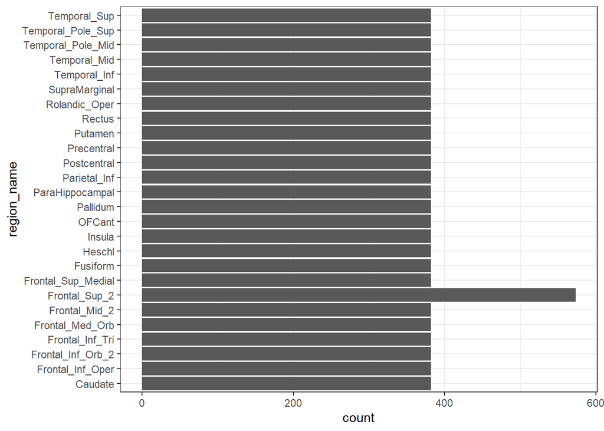

```r
fdg_regional_lf %>%
  ggplot(mapping = aes(y = region_name)) +
  geom_bar() +
  theme_bw()
```

Include the side.

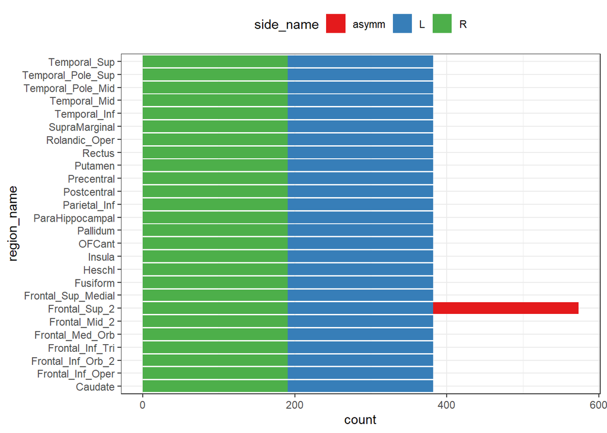

```r
fdg_regional_lf %>%
  ggplot(mapping = aes(y = region_name)) +
  geom_bar(mapping = aes(fill = side_name)) +
  scale_fill_brewer(palette = "Set1") +
  theme_bw() +
  theme(legend.position = 'top')
```

Distributions of FDG values per region and side. Note the x-axis scales are the same in each facet.

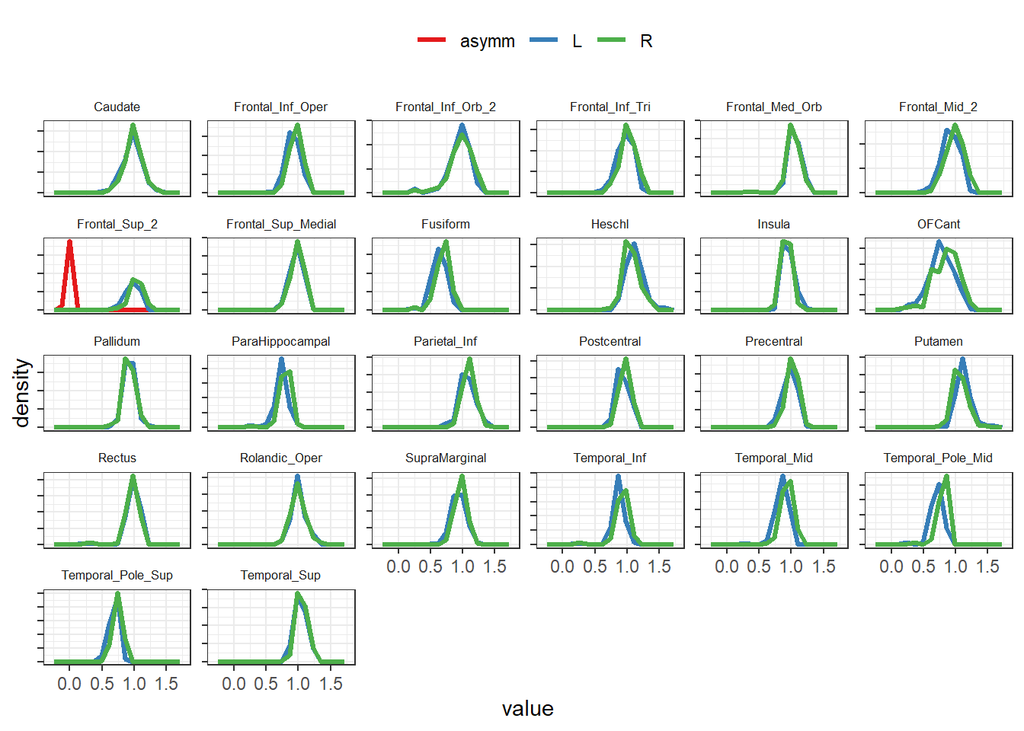

```r
fdg_regional_lf %>%
  ggplot(mapping = aes(x = value)) +
  geom_freqpoly(mapping = aes(color = side_name,
                              group = interaction(region_name,
                                                  side_name),
                              y = stat(density)),
                size = 1.2,
                bins = 15) +
  facet_wrap(~region_name, scales = "free_y") +
  scale_color_brewer("", palette = "Set1") +
  theme_bw() +
  theme(legend.position = 'top',
        axis.text.y = element_blank(),
        strip.background = element_blank(),
        strip.text = element_text(size = 6.5))
```

Allow the x-axis scales to vary across facets. kept the bin number constant zoom in to see the plot

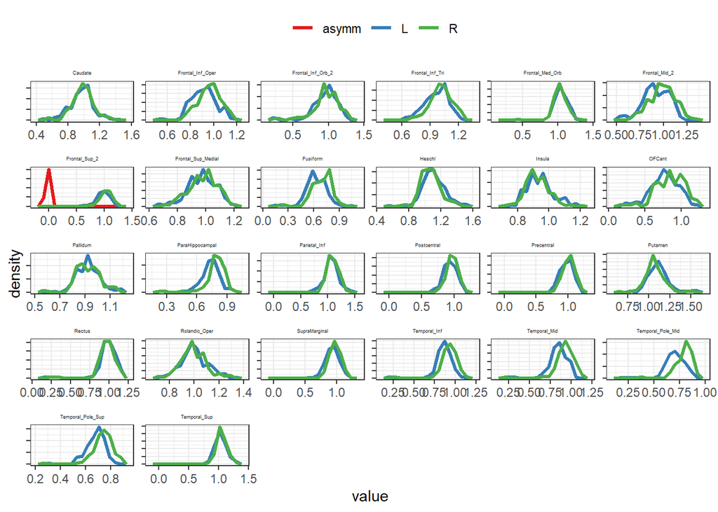

```r
fdg_regional_lf %>%
  ggplot(mapping = aes(x = value)) +
  geom_freqpoly(mapping = aes(color = side_name,
                              group = interaction(region_name,
                                                  side_name),
                              y = stat(density)),
                size = 1.2,
                bins = 15) +
  facet_wrap(~region_name, scales = "free") +
  scale_color_brewer("", palette = "Set1") +
  theme_bw() +
  theme(legend.position = 'top',
        axis.text.y = element_blank(),
        strip.background = element_blank(),
        strip.text = element_text(size = 3.5))
```

Check the behavior of the repeated observations per person. The x-axis corresponds to a unique `Vault_UID` but the axis text has been turned off to make the plots easier to read.

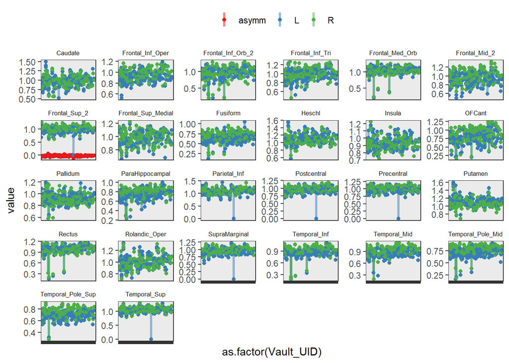

```r
fdg_regional_lf %>%
  ggplot(mapping = aes(x = as.factor(Vault_UID), y = value)) +
  stat_summary(geom = 'linerange',
               fun.min = 'min', fun.max = 'max',
               mapping = aes(group = interaction(Vault_UID,
                                                 region_name,
                                                 side_name),
                             color = side_name),
               position = position_dodge(0.1),
               size = 1.2, alpha = 0.5) +
  geom_point(mapping = aes(group = interaction(Vault_UID,
                                               region_name,
                                               side_name),
                           color = side_name),
             position = position_dodge(0.1)) +
  facet_wrap(~region_name, scales = 'free_y') +
  scale_color_brewer("", palette = "Set1") +
  theme_bw() +
  theme(legend.position = 'top',
        axis.text.x = element_blank(),
        strip.background = element_blank(),
        strip.text = element_text(size = 6.5))
```

Focused on a single region.

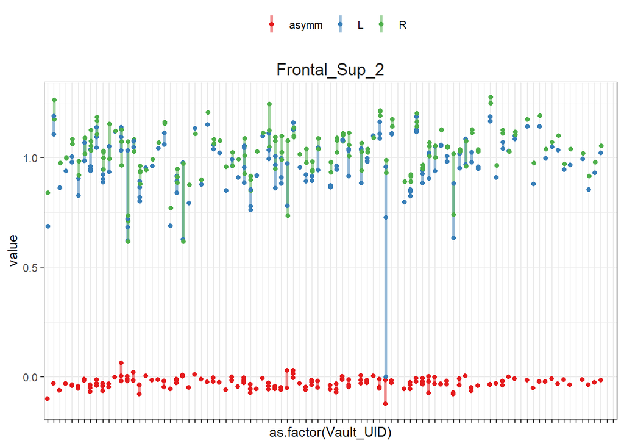

```r
fdg_regional_lf %>%
  filter(region_name %in% 'Frontal_Sup_2') %>%
  ggplot(mapping = aes(x = as.factor(Vault_UID), y = value)) +
  stat_summary(geom = 'linerange',
               fun.min = 'min', fun.max = 'max',
               mapping = aes(group = interaction(Vault_UID,
                                                 region_name,
                                                 side_name),
                             color = side_name),
               position = position_dodge(0.2),
               size = 1.2, alpha = 0.5) +
  geom_point(mapping = aes(group = interaction(Vault_UID,
                                               region_name,
                                               side_name),
                           color = side_name),
             position = position_dodge(0.2)) +
  facet_wrap(~region_name, scales = 'free_y') +
  scale_color_brewer("", palette = "Set1") +
  theme_bw() +
  theme(legend.position = 'top',
        axis.text.x = element_blank(),
        strip.background = element_blank(),
        strip.text = element_text(size = 13.5))
```